# P4 Salud_Mental

# **IMPACTO DEL COVID-19 EN LA SALUD MENTAL DE LOS ESTUDIANTES DE UTEC DESDE EL 2020 HASTA LA ACTUALIDAD**

### Indice

1. Introducción
2. Objetivos
3. Marco teórico
4. Descriptores numéricos
5. Correlación de variables
6. Análisis de variables aleatorias
7. Parámetro de estudios
8. Prueba de hipótesis
9. Regresión lineal
10. Variables independientes
11. variables dependientes

#### **1. Introducción**

Según la OMS(2017) se define a salud mental como un “estado de completo bienestar físico, mental y social, y no solamente la ausencia de afecciones o enfermedades”, por lo tanto, consideramos que es un tema muy importante y de sumo interés ya que afecta la forma en que pensamos, sentimos y actuamos cuando enfrentamos la vida. También ayuda a determinar cómo manejamos el estrés, nos relacionamos con los demás y tomamos decisiones. Como bien sabemos la situación que estamos atravesando debido a la pandemia generada por el Covid-19 nos ha puesto en una situación bastante difícil, teniendo que lidiar con diferentes factores que afectan nuestra salud emocional y por lo tanto, también causa repercusión en nuestro desempeño como estudiantes.

#### **2. Objetivos**

- Realizar un estudio para recolectar datos de diferentes variables que podrian afectar la salud emocional de los estudiantes de UTEC.
- Establecer relaciones entre factores ocasionados por la pandemia generada por el Covid-19 y la salud emocional de los estudiantes de UTEC.
- Analizar el impacto del Covid-19 en la salud emocional de los Estudiantes de UTEC

#### **3. Marco teórico**

##### **Población Objetiva**

- Estudiantes de UTEC

##### **Tipo de Muestra**

- La muestra seleccionada fue por conveniencia. Para obtener nuestra base de datos se realizó una encuesta, de elaboración propia.

##### **Sesgo**

- De Selección

##### **Variables**

| Variable (abreviación) | Significado | Tipo de variable | Descripción |
| --- | --- | --- | --- |
| *Edad* | Edad | Variable Numérica Discreta | Edad de los estudiantes de UTEC que participaron en la muestra |
| *Ciclo* | Ciclo universitario | Variable Categórica Ordinal | Ciclo que cursó o está cursando el estudiante en UTEC |
| *Codigo* | Código universitario | Variable Categórica Ordinal | Código del estudiante en UTEC |
| *Residencia* | Residencia | Variable Categórica Nominal | Lugar de residencia del estudiante |
| *Tfamiliar* | Tamaño familiar | Variable Numérica Discreta | Cantidad de personas que viven en el hogar del estudiante |
| *Contagiado* | Familiares contagiados | Variable Categórica Nominal | Si algún miembro de tu familia se ha contagiado de COVID-19 |
| *CantidadC* | Cantidad total de contagiados en la familia | Variable Numérica Discreta | Cantidad de personas contagiadas o que se han contagiado de COVID- 19 en el hogar |
| *Fallecidos* | Fallecidos | Variable Categórica nominal | Se refiere a si en su hogar alguno de sus familiares ha fallecido a causa de COVID-19 |
| *Sobrellevar* | Sobrellevar la situación | Variable Categórica Ordinal | Grado de dificultad que resultó sobrellevar la situación en el caso de haber tenido familiares contagiados o que han fallecido a causa del COVID-19. Escala del 1 al 5. |
| *Ansiedad* | Ansiedad | Variable categórica Nominal | Indica si durante la pandemia ha sufrido ataques de ansiedad |
| *Ayudaprofesional* | Ayuda profesional | Variable categórica Nominal | Ayuda profesional recibida en caso de haber sufrido ataques de ansiedad |
| *Medicacion* | Medicación | Variable Categórica Nominal | Necesidad o consumo de medicación para controlar los ataques de ansiedad |
| *Amigos* | Amigos | Variable Numérica Discreta | Tiempo que el estudiante solía pasar con sus amigos antes de la pandemia al día en horas |
| *Contacto* | Contacto | Variable Categórica Nominal | Contacto que se mantiene con amigos o conocidos, en este caso, indica si se perdió o no |
| *Afectacion* | Afectación | Variable Categórico Ordinal | Nivel de afectación en caso de haber perdido contacto con amigos y conocidos a causa de la pandemia. Escala del 1 al 5. |
| *Tareashogar* | Tareas en el hogar | Variable Categórica Ordinal | Cómo percibe el estudiante que su tiempo libre ha sido afectado por presentar más tareas del hogar debido a estar más tiempo en casa. Escala del 1 al 5. |
| *Tlibre* | Tiempo libre | Variable Numérica Discreta | Tiempo netamente libre durante el día en horas |
| *Saludmental* | Salud mental | Variable Categórica Nominal | Consideración respecto a si la pandemia influye en la salud mental |

#### **4. Descriptores numéricos**

En primer lugar, se analizaron las principales **variables numéricas**

```
##            Edades N°Familiares N°contagios_por_familia Tiempo_con_Amigos
## Min        16     1            0                       0.5
## Max        30     24           15                      5
## Media      19.01  4.4          1.59                    3.54
## Mediana    19     4            1                       4
## Desviacion 1.92   2.78         2.37                    1.57
## CV         0.1    0.63         1.49                    0.44
##            Tiempo_libre
## Min        0
## Max        13
## Media      4.86
## Mediana    6
## Desviacion 3.18
## CV         0.66
```

**Observaciones**

- Los valores del N°contagios_por_familia de los estudiantes de UTEC están muy dispersos.
- Al menos la mitad de los estudiantes vive con 4 familiares bajo el mismo techo.
- Al menos la mitad de los estudiantes ha tenido 1 familiar que se contagió por Covid.

**Edad**

| DESCRIPTOR NUMÉRICO | Edad |
| --- | --- |
| Min | 16 |
| Max | 30 |
| Media | 19.01 |
| Mediana | 19 |
| Desviación | 1.92 |
| CV | 0.1 |

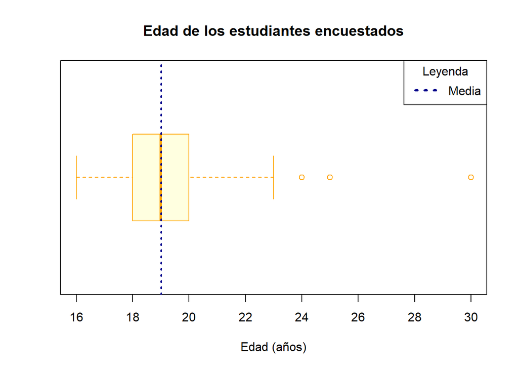

**Observaciones:**

- Se observan 3 datos atípicos
- La gráfica es simétrica.
- la desviación estándar es de 1.92, lo que nos indica que las edades están bien dispersas.
- la media tiene un valor mayor que la mediana.

**Tamaño Familiar**

| DESCRIPTOR NUMÉRICO | Tamaño Familiar |
| --- | --- |
| Min | 1 |
| Max | 24 |
| Media | 4.4 |
| Mediana | 4 |
| Desviación | 2.78 |
| CV | 0.63 |

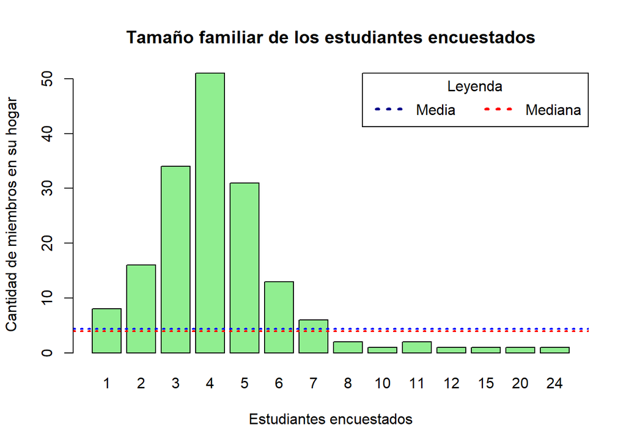

**Observaciones:**

**Cantidad de Contagiados por Covid-19**

| DESCRIPTOR NUMÉRICO | Cantidad de contagiados |
| --- | --- |
| Min | 0 |
| Max | 15 |
| Media | 1.59 |
| Mediana | 1 |
| Desviación | 2.37 |
| CV | 1.49 |

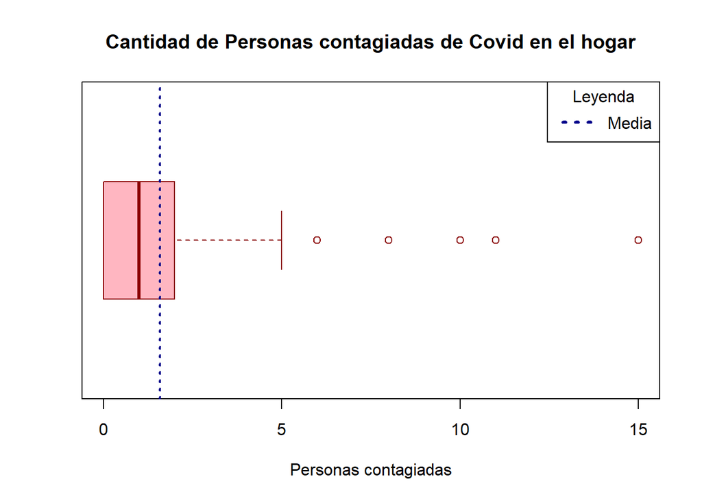

**Observaciones:**

**Tiempo que solía pasar con sus amigos antes de la pandemia**

[output not shown]

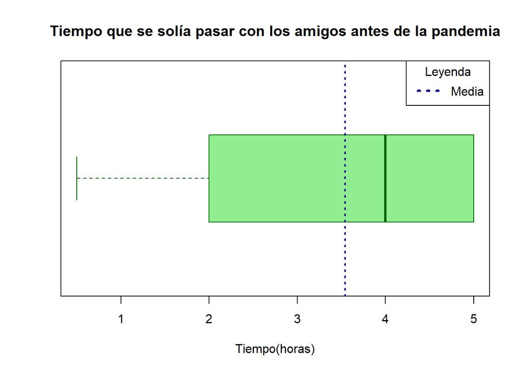

**Observaciones:**

[output not shown]

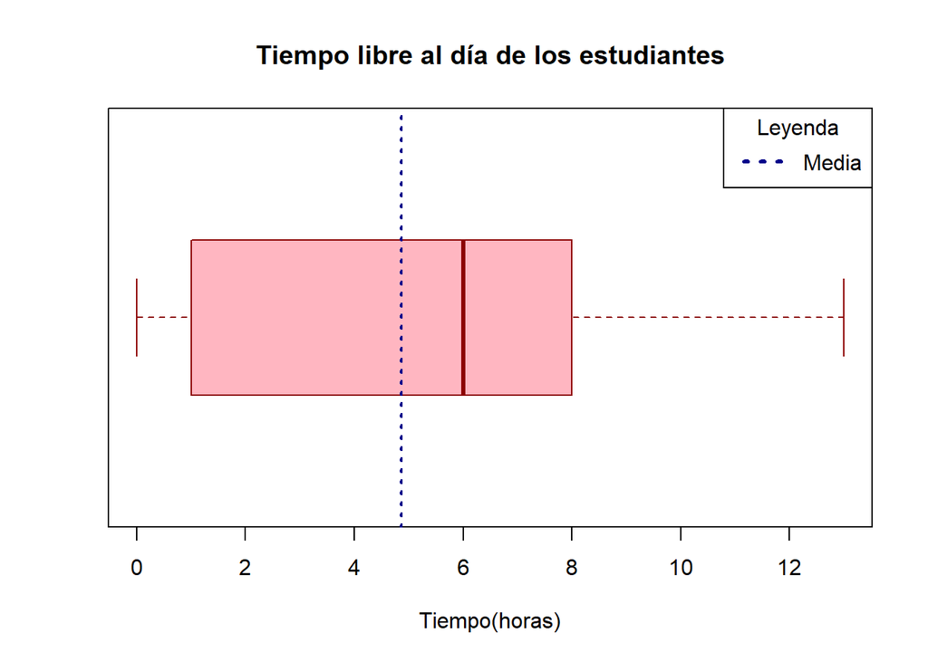

**Observaciones:**

Personas con familiares que padecen de enfermedades mentales previas a la pandemia

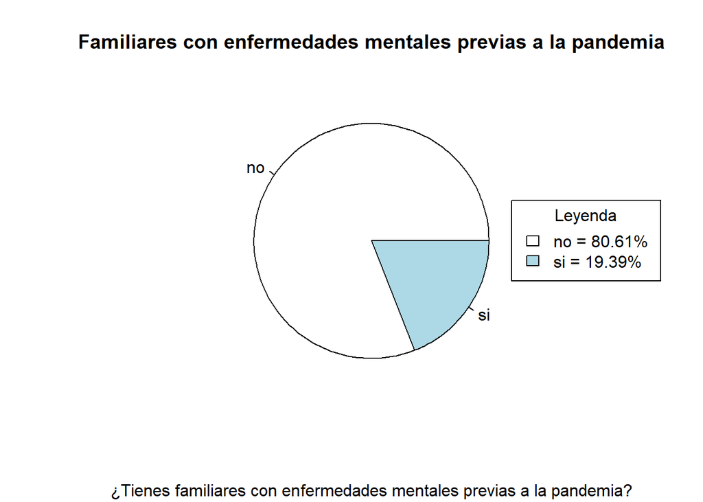

```r
table(DFN$EnfermedadesM)
```

```
##
##  no  si
## 136  32
```

**Observaciones:**

#### **5. Correlación de variables**

#### **Tiempo libre de los estudiantes Vs Edad**

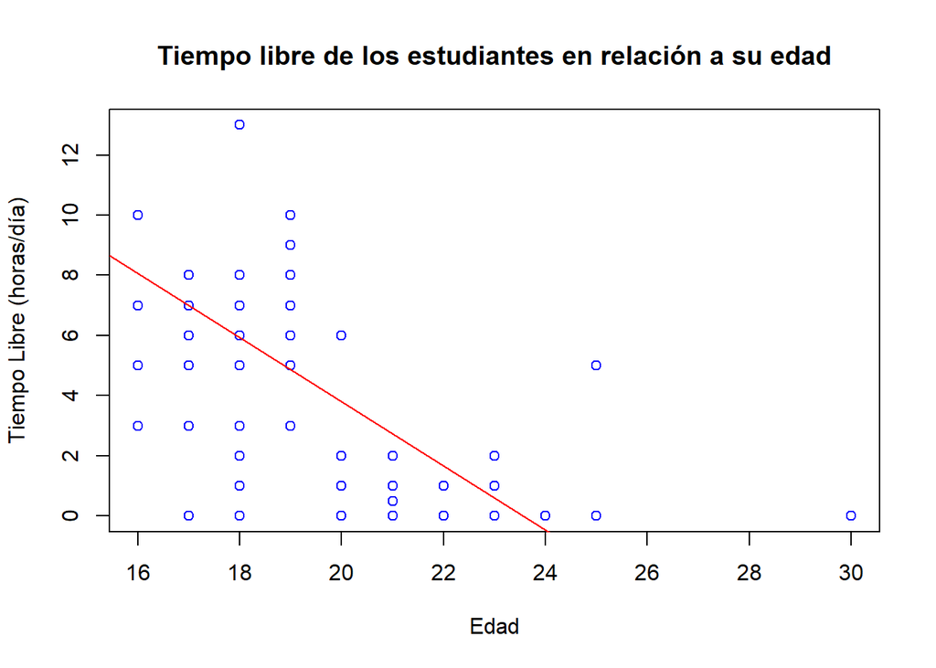

##### Cálculo de la covarianza entre las variables edad y tiempo libre.

```r
cor(DFN$Edad,DFN$Tlibre)
```

```
## [1] -0.6444672
```

**Observaciones:**

- La relación entre la variable edad (Edad) y la variable Tiempo libre (Tlibre) es fuerte y negativa.
- Esta relación nos sugiere que mientras la variable edad aumente, la variable tiempo libre irá disminuyendo.

#### Consideraciones acerca de la afectación de la salud mental en relación con la edad

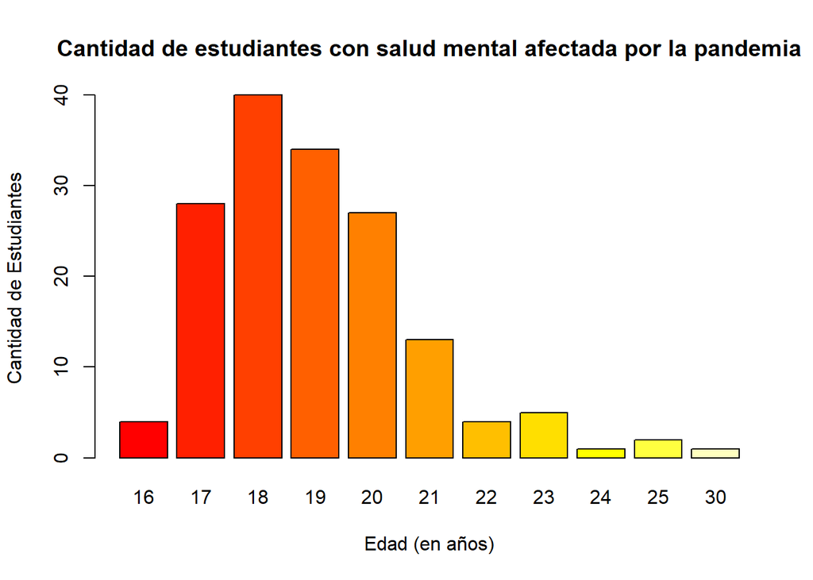

#### Pérdida de contacto con amigos y/o conocidos relacionados con ataques de ansiedad.

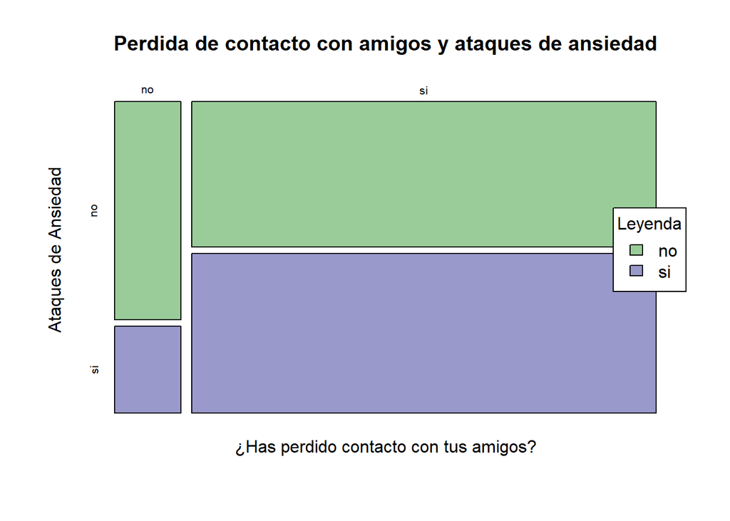

**Observaciones:**

- Pese a que los estudiantes han perdido contacto con sus amigos, esto no se relaciona con los ataques de ansiedad sufridos en la mayoría de los casos.

Tamaño familiar relacionado con la cantidad de contagiados

[figure not shown]

```r
cor(DFN$Tfamiliar,DFN$CantidadC)
```

```
## [1] 0.2580174
```

**Observaciones:** - No hay una relación fuerte entre las variables Tamaño familiar y Cantidad de contagiados

Tamaño familiar relacionado con la cantidad de miembros de la familia contagiados de Covid y ataques de ansiedad

**Hipótesis:** Los estudiantes que han presentado ataques de ansiedad durante la pandemia, tienen una mayor cantidad de familiares contagiados.

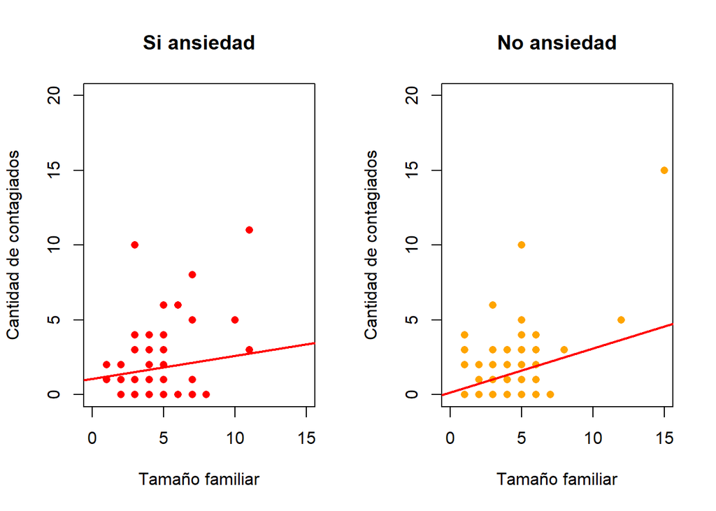

- Correlación entre el tamaño familiar y cantidad de personas contagiadas dentro del un hogar ha causado o no ansiedad en el estudiante de UTEC en el estudio

```
## [1] 0.19
```

```
## [1] 0.33
```

**Observaciones**

- La correlación entre las variables tamaño familiar y cantidad de personas contagiadas dentro de un hogar ha causado ansiedad en el estudiante es débil y positiva.
- La correlación entre las variables tamaño familiar y cantidad de personas contagiadas dentro de un hogar no ha causado ansiedad en el estudiante es es mas fuerte que la comparación anterior y positiva.

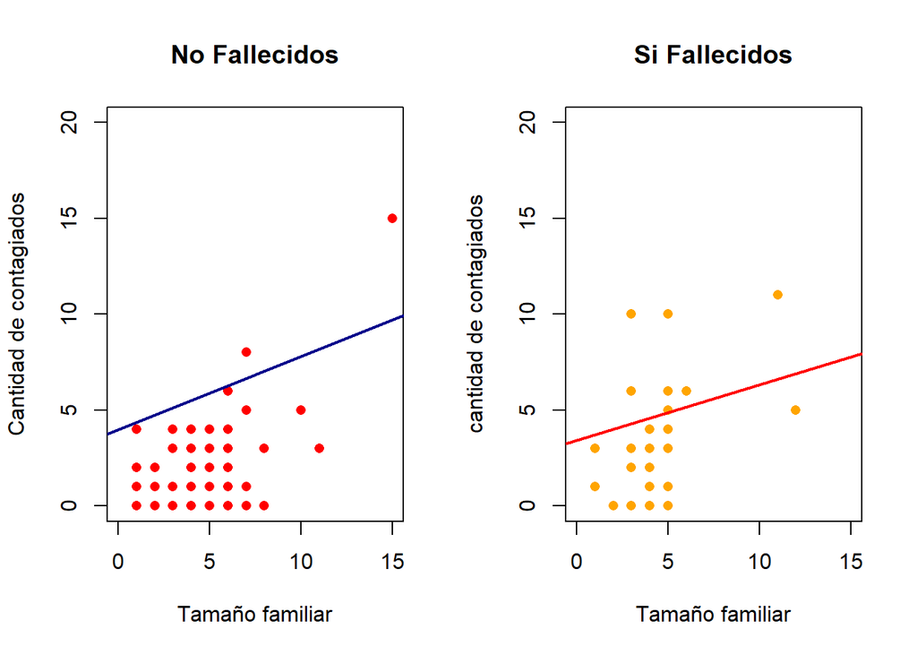

##### Cálculo de la covarianza entre las variables tamaño familiar y cantidad de fallecidos en las familias.

```r
cor(DFN$Tfamiliar[DFN$Fallecidos == "no"], DFN$CantidadC[DFN$Fallecidos == "no"])
```

```
## [1] 0.2588808
```

```r
cor(DFN$Tfamiliar[DFN$Fallecidos == "si"], DFN$CantidadC[DFN$Fallecidos == "si"])
```

```
## [1] 0.4143542
```

**Observaciones**

- La correlación entre las variables tamaño familiar y cantidad de personas contagiadas dentro del hogar del estudiante en el que no hubo fallecidos, es débil y positiva.
- La correlación entre las variables tamaño familiar y cantidad de personas contagiadas dentro de un hogar del estudiante en el que hubo amenos 1 fallecido, es relativamente débil y positiva.
- De la gráfica en la que hubo almenos un fallecido, se puede observar que si el tamaño familiar crece existe la posibilidad de que la cantidad de contagiados también crezca.

Nivel de Afectación a su salud emocional relacionado con la cantidad de miembros fallecidos de su familia

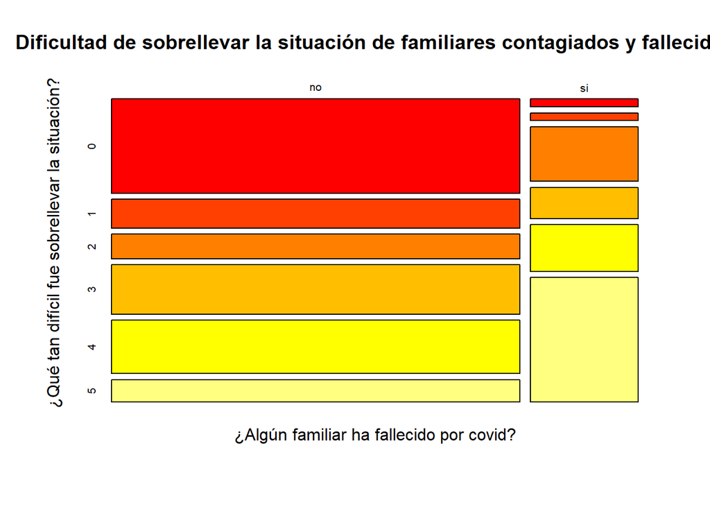

**Observaciones:**

#### **6. Análisis de variables aleatorias**

*Pregunta*: ¿Qué tan probable es que un alumno de Primer ciclo haya tenido ataques de Ansiedad?

```
##
##  1
## 56
```

```
##
## si
## 83
```

```r
p2<- (sum(Cons1 & Cons2)/168)/(sum(Cons2)/168)
round(p2, digits = 2)
```

```
## [1] 0.01
```

La probabilidad de que un alumno de primer ciclo haya tenido ataques de ansiedad durante la pandemia es 0.01.

Teniendo en cuenta, que de 168 estudiantes encuestados, 45 de ellos se encuentran en provincia:

*Pregunta*: ¿Qué tan probable es que un alumno que vive en provincia tenga al menos un familiar que ha fallecido por Covid ?

A: Estudiantes que residen en provincia

B: Estudiantes que tienen al menos un familiar fallecido a causa de Covid

```
##
## Fuera de Lima (Provincia)
##                        45
```

```
##
## si
## 35
```

```
## [1] 0.03
```

**Análisis**:

*Pregunta:* ¿Qué probabilidad hay de que un alumno que tiene familiares con enfermedades mentales previas a la pandemia haya tenido ataques de ansiedad?

E1: Alumnos que tienen familiares con enfermedades previas a la pandemia

E2: Alumnos que han sufrido ataques de ansiedad durante la pandemia

```
##
## si
## 32
```

```
##
## si
## 83
```

```r
p3<- (sum(E1 & E2)/168)/(sum(E2)/168)
round(p3, digits = 2)
```

```
## [1] 0.01
```

La probabilidad de que un alumno que tiene un familiar con enfermedades mentales previas a la pandemia es de 0.01.

### *Discreta: Modelo Binomial*

##### *Variable: Considera que la pandemia afectó la salud mental (Saludmental)*

##### Criterios de análisis

*Dónde:*

- Éxito -> La pandemia SI afectó la salud mental de los estudiantes encuestados
- Fracaso -> La pandemia NO afectó la salud mental de los estudiantes encuestados

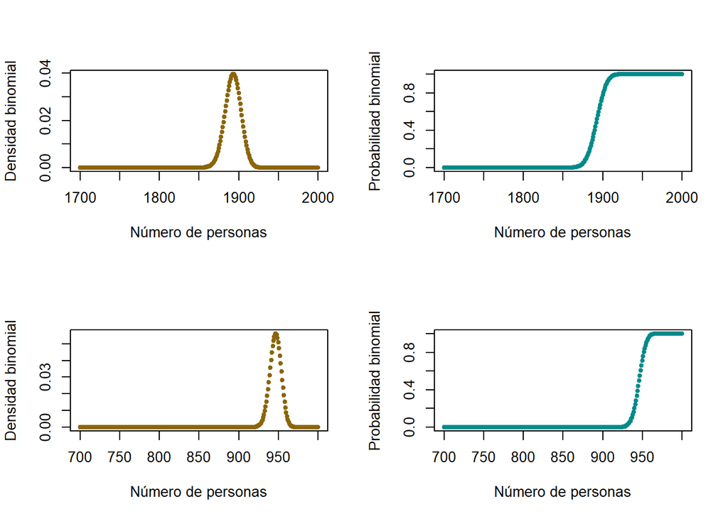

### *Continua: Modelo exponencial*

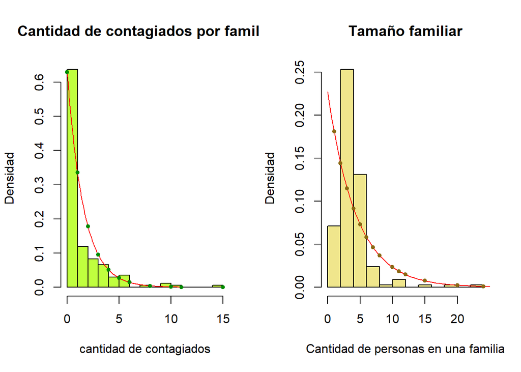

#### **7. Parámetros de estudio**

**Muestra:**

Para el estudio planteado, se emplea un muestreo no probabilístico, la técnica utilizada es el muestreo por conveniencia.

*Tamaño de la muestra:* 168 estudiantes *Nivel de confianza:* 95% *Significancia:* 0.05 *Representatividad:*

Cantidad de estudiantes por año

| 2016 | 2017 | 2018 | 2019 | 2020 | 2021 |
| --- | --- | --- | --- | --- | --- |
| 2 | 15 | 22 | 48 | 27 | 54 |

#### **8. Prueba de hipótesis**

*Hipótesis planteadas*

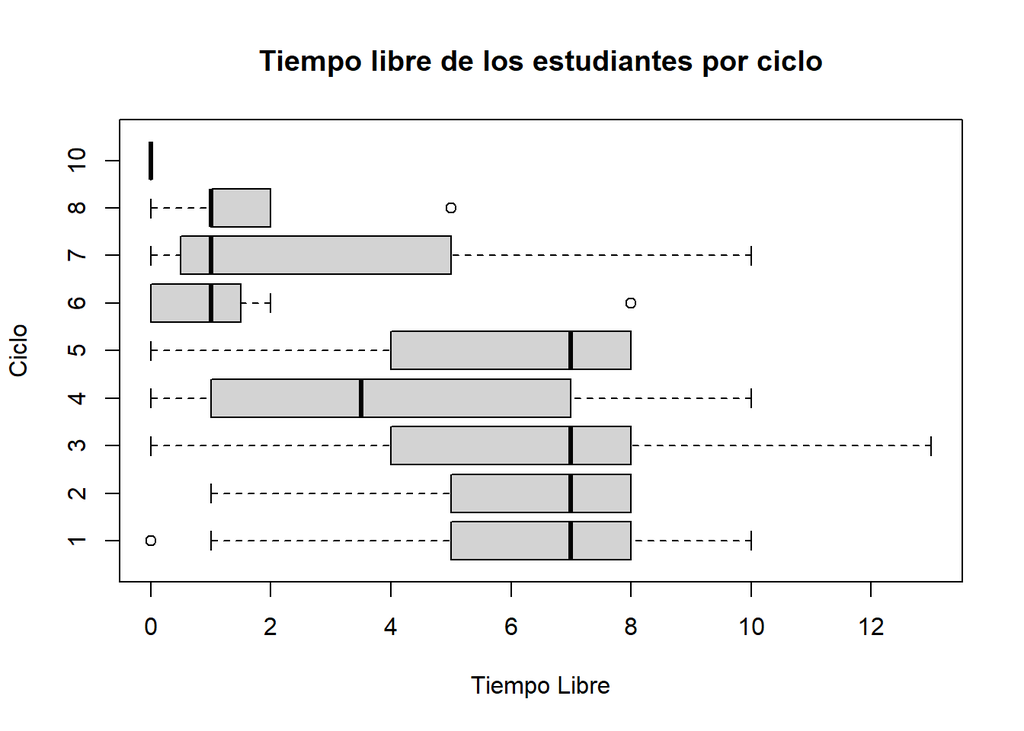

- ¿Los estudiantes de primer ciclo tienen alrededor de 6 horas libres al día?

H0: Los estudiantes de primer ciclo tienen >= 6 horas libres al día

H1: Los estudiantes de primer ciclo tienen < 6 horas libres al día

$H_0 :\mu \geq$ 6 horas libres al día.

$H_a :\mu <$ 6 horas libres al día.

### **Resultados de la hipótesis 1**

- Estadístico de prueba : -3.3845
- Valor crítico: -1.673
- p-valor: 7^{-4}
- Prueba de hipótesis Unilateral izquierda:
- Precisión: -0.5635

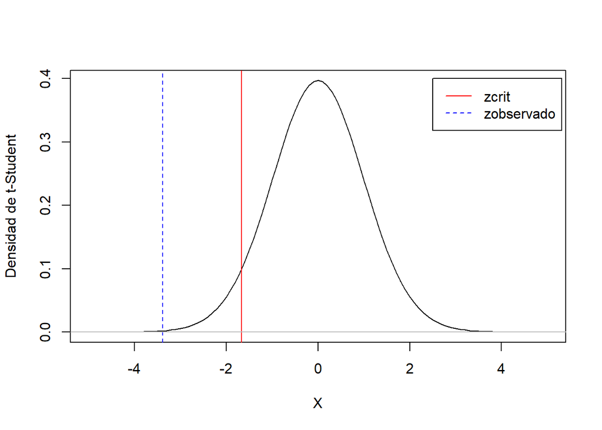

**Conclusiones:**

**¿los estudiantes que han perdido familiares a causa del Covid tienen una media de nivel de afectación emocional menor igual a 3?**

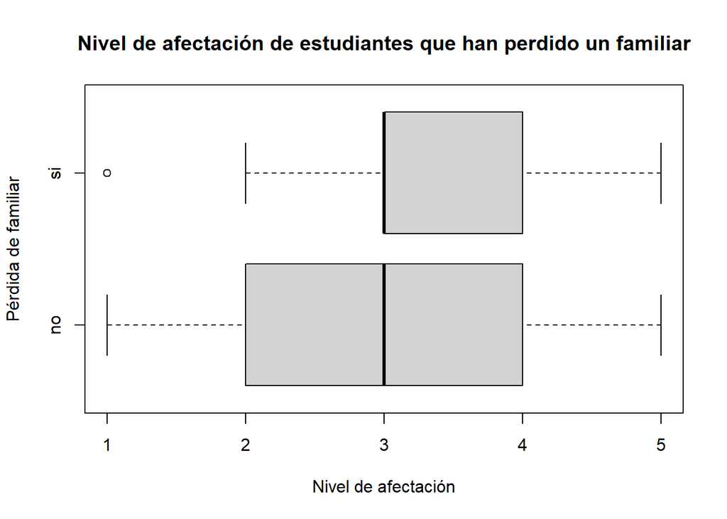

H0: Los estudiantes que han perdido almenos un familiar tienen un nivel de afectación emocional menor o igual a 3

H1:Los estudiantes que han perdido almenos un familiar tienen un nivel de afectación emocional mayor a 3

$H_0 :\mu \leq$ 3

$H_a :\mu >$ 3

### **Resultados de la hipótesis 2**

- Estadístico de prueba : 0.8814
- Valor crítico: 1.6909
- p-valor: 0.1921
- Prueba de hipótesis Unilateral derecha:
- Precisión: 0.2969

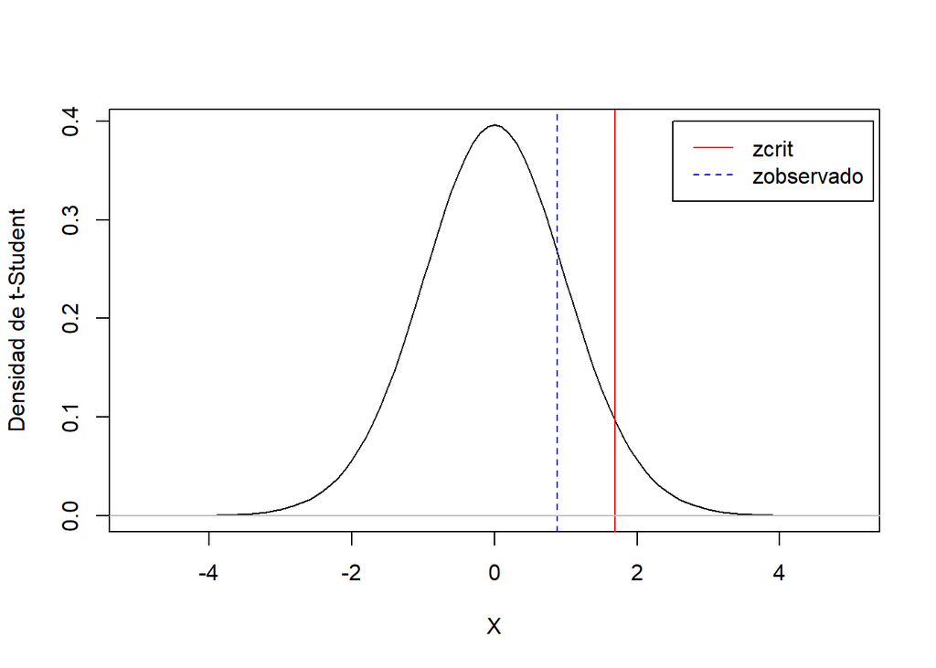

**Conclusiones:**

**¿Los estudiantes que han perdido contacto con sus amigos tienen mas de 6 horas libres al día?**

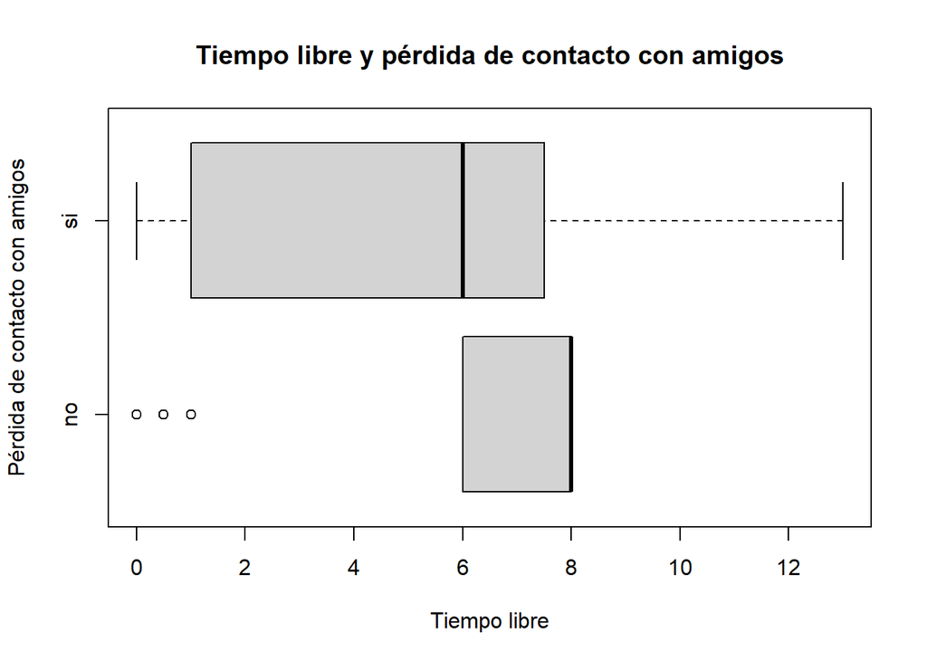

H0: Los estudiantes que han perdido contacto con sus amigos tienen mayor o igual 6 horas libres al día.

H1: Los estudiantes que han perdido contacto con sus amigos tienen menos de 6 horas libres al día.

$H_0 :\mu \geq$ 6

$H_a :\mu <$ 6

### **Resultados de la hipótesis 3**

- Estadístico de prueba : -4.368
- Valor crítico: -1.6554
- p-valor: 0
- Prueba de hipótesis Unilateral izquierda:
- Precisión: -0.432

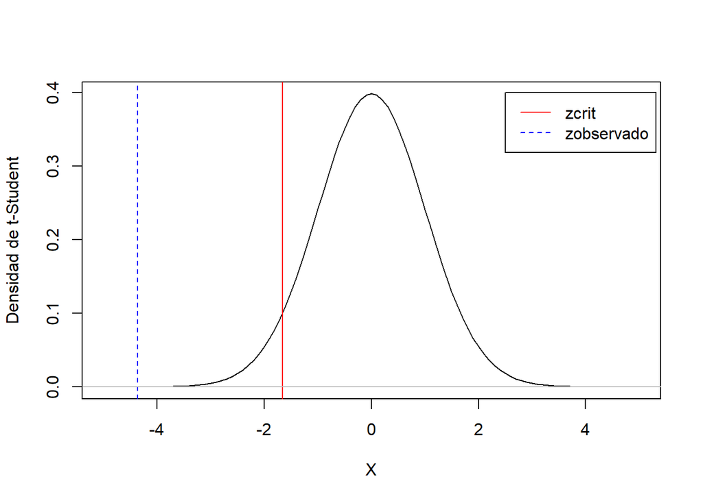

Hay suficiente evidencia para rechazar la hipótesis nula.

#### **9. Regresión Lineal**

**Regresión entre tiempo libre y edad**

¿Mientras los estudiantes tengan mas edad su tiempo libre es menor?

*Realizamos el test de cor.test para verificar si es que hay una relación entre estas variables*

```r
cor.test(DFN$Tlibre, DFN$Edad)
```

```
##
##  Pearson's product-moment correlation
##
## data:  DFN$Tlibre and DFN$Edad
## t = -10.859, df = 166, p-value < 2.2e-16
## alternative hypothesis: true correlation is not equal to 0
## 95 percent confidence interval:
##  -0.7251207 -0.5463716
## sample estimates:
##        cor
## -0.6444672
```

Con esto comprobamos que hay una relación fuerte entre las variables Tiempo libre y edad, ya que el valor de la correlación es de -0.64.

*Resumen de la regresión*

```r
modelo1<-lm(DFN$Tlibre ~ DFN$Edad)
summary(modelo1)
```

```
##
## Call:
## lm(formula = DFN$Tlibre ~ DFN$Edad)
##
## Residuals:
##     Min      1Q  Median      3Q     Max
## -7.0022 -1.7986  0.0657  2.0657  7.0657
##
## Coefficients:
##             Estimate Std. Error t value Pr(>|t|)
## (Intercept) 25.15572    1.87843   13.39   <2e-16 ***
## DFN$Edad    -1.06785    0.09834  -10.86   <2e-16 ***
## ---
## Signif. codes:  0 '***' 0.001 '**' 0.01 '*' 0.05 '.' 0.1 ' ' 1
##
## Residual standard error: 2.443 on 166 degrees of freedom
## Multiple R-squared:  0.4153, Adjusted R-squared:  0.4118
## F-statistic: 117.9 on 1 and 166 DF,  p-value: < 2.2e-16
```

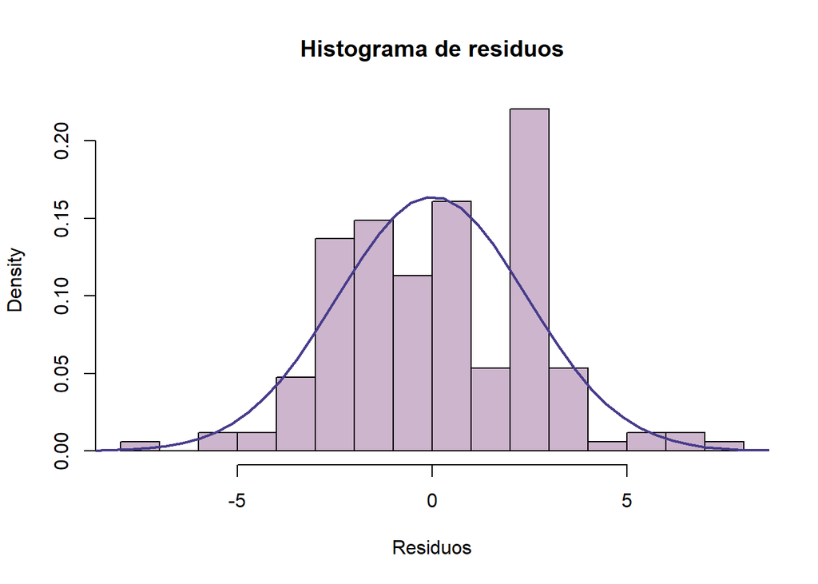

```r
hist(modelo1$residuals, breaks= 20,main="Histograma de residuos", col="thistle3", xlab = "Residuos", freq = FALSE)
curve(dnorm(x, mean(modelo1$residuals), sd = sd(modelo1$residuals)), # Función dnorm a evaluar
      -50, 20,168, # Límites de x y nº de valores a evaluar
      col = "slateblue4",
      lwd= 2,
      las = 1, # Etiquetas alineadas horizontalmente
      ann = FALSE, # Sin títulos en los ejes
      xaxp = c(-15, 15, 5),  # Marcas del eje x
      ylim = c(0,0.05), # Límites del eje
      yaxs = "i", add=TRUE) # Estilo del eje y, ajustado a los límites
```

**Observaciones:**

```r
mean(modelo1$residuals)
```

```
## [1] 6.52651e-17
```

- Residuales
  - La media de los residuos es 6.5265099^{-17}, cuyo valor es cercano a 0.
  - La gráfica se aproxima a una forma simétrica
- Coeficientes
  - Intercepto: Para una significancia de 0.05, se rechaza la H0, así que b≠0.
  - Pendientes: Para una significancia de 0.05, se rechaza la H0 (m=0), es decir, que sí existe relación entre las variables.
- R^2
  - El modelo se adecúa para el 42% de los datos de nuestra muestra.
- p-value
  - Para una significancia de 0.05, se rechaza la H0 de que el modelo no explica nada, es decir, que la edad explica en cierto grado las horas libres de las que dispone un estudiante de UTEC al día.

*Nuestra variable independiente es la edad y la variable dependiente es el tiempo libre*

```r
(modelo1$coefficients)
```

```
## (Intercept)    DFN$Edad
##   25.155718   -1.067855
```

*Ecuación de predicción:*

**Tiempo libre = - 1.067855*Edad + 25.155718**

*Modelo de la ecuación de predicción*

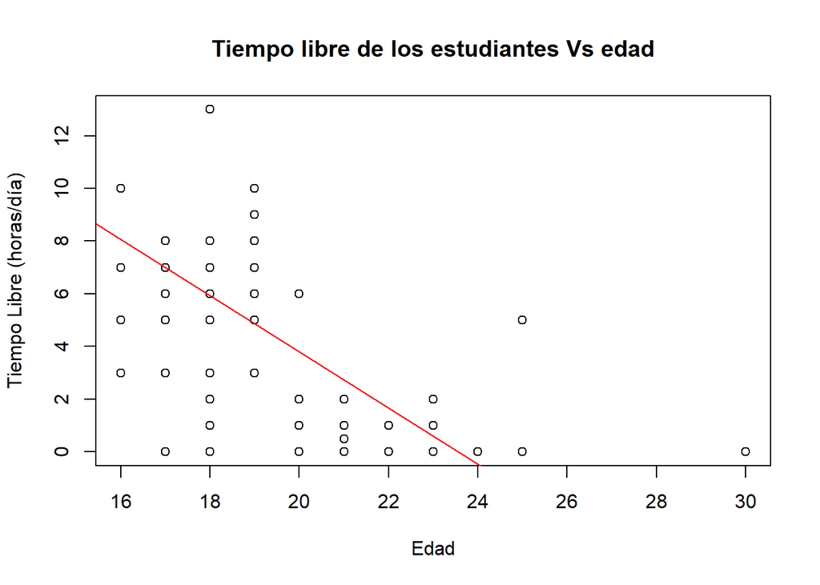

*Observaciones:*

**Regresión entre tamaño familiar y cantidad de miembros de la familia contagiados**

¿Mientras más grande es el tamaño familiar hay más contagiados en la familia?

*Realizamos el test de cor.test para verificar si es que hay una relación entre estas variables*

```r
cor.test(DFN$CantidadC, DFN$Tfamiliar)
```

```
##
##  Pearson's product-moment correlation
##
## data:  DFN$CantidadC and DFN$Tfamiliar
## t = 3.4408, df = 166, p-value = 0.0007337
## alternative hypothesis: true correlation is not equal to 0
## 95 percent confidence interval:
##  0.1109417 0.3940337
## sample estimates:
##       cor
## 0.2580174
```

*Resumen de la regresión*

```r
modelo2<-lm(DFN$CantidadC ~ DFN$Tfamiliar)
summary(modelo2)
```

```
##
## Call:
## lm(formula = DFN$CantidadC ~ DFN$Tfamiliar)
##
## Residuals:
##     Min      1Q  Median      3Q     Max
## -5.8988 -1.5003 -0.7803  0.9396 11.0806
##
## Coefficients:
##               Estimate Std. Error t value Pr(>|t|)
## (Intercept)    0.62057    0.33249   1.866 0.063742 .
## DFN$Tfamiliar  0.21993    0.06392   3.441 0.000734 ***
## ---
## Signif. codes:  0 '***' 0.001 '**' 0.01 '*' 0.05 '.' 0.1 ' ' 1
##
## Residual standard error: 2.293 on 166 degrees of freedom
## Multiple R-squared:  0.06657,    Adjusted R-squared:  0.06095
## F-statistic: 11.84 on 1 and 166 DF,  p-value: 0.0007337
```

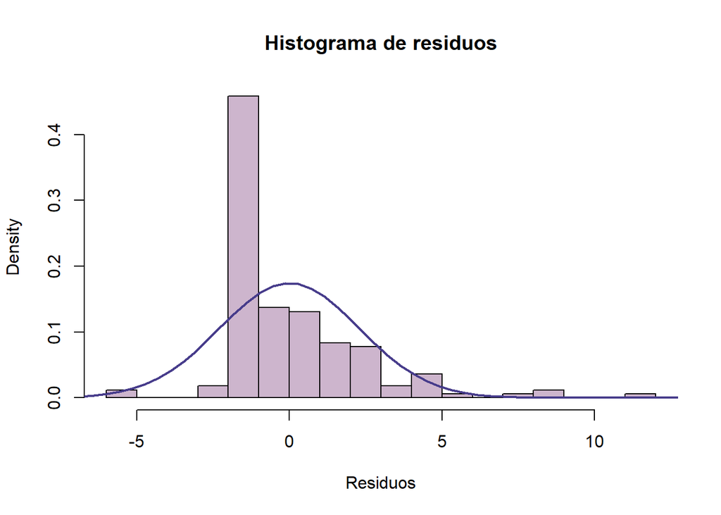

```r
hist(modelo2$residuals, breaks= 20,main="Histograma de residuos", col="thistle3", xlab = "Residuos", freq = FALSE)
curve(dnorm(x, mean(modelo2$residuals), sd = sd(modelo2$residuals)), # Función dnorm a evaluar
      -50, 20,168, # Límites de x y nº de valores a evaluar
      col = "slateblue4",
      lwd= 2,
      las = 1, # Etiquetas alineadas horizontalmente
      ann = FALSE, # Sin títulos en los ejes
      xaxp = c(-15, 15, 5),  # Marcas del eje x
      ylim = c(0,0.5), # Límites del eje
      yaxs = "i", add=TRUE) # Estilo del eje y, ajustado a los límites
```

**Observaciones:**

```r
mean(modelo2$residuals)
```

```
## [1] -3.533725e-17
```

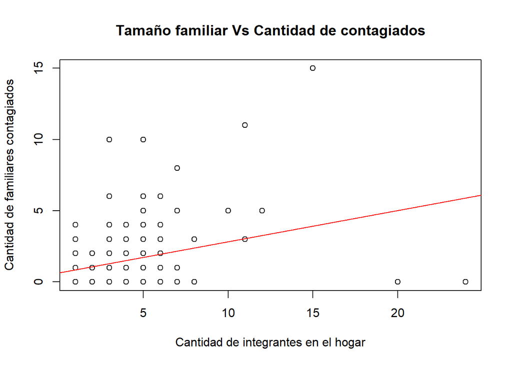

**Observaciones:**

- La relación entre estas variables es débil.
- Esto nos indica que no necesariamente a mayor tamaño familiar hay un mayor cantidad de contagiados.

*Resumen de la regresión*

```r
modelo3<-lm(DFN$Tlibre~DFN$Edad+DFN$Ciclo)
summary(modelo3)
```

```
##
## Call:
## lm(formula = DFN$Tlibre ~ DFN$Edad + DFN$Ciclo)
##
## Residuals:
##     Min      1Q  Median      3Q     Max
## -7.0904 -1.7425  0.0036  2.0036  7.0751
##
## Coefficients:
##             Estimate Std. Error t value Pr(>|t|)
## (Intercept) 24.54362    2.06149  11.906  < 2e-16 ***
## DFN$Edad    -1.02245    0.11667  -8.764  2.2e-15 ***
## DFN$Ciclo   -0.07156    0.09859  -0.726    0.469
## ---
## Signif. codes:  0 '***' 0.001 '**' 0.01 '*' 0.05 '.' 0.1 ' ' 1
##
## Residual standard error: 2.446 on 165 degrees of freedom
## Multiple R-squared:  0.4172, Adjusted R-squared:  0.4101
## F-statistic: 59.06 on 2 and 165 DF,  p-value: < 2.2e-16
```

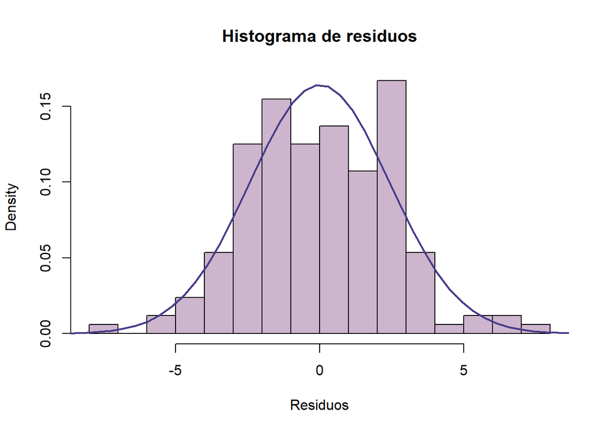

```r
hist(modelo3$residuals, breaks= 20,main="Histograma de residuos", col="thistle3", xlab = "Residuos", freq = FALSE)
curve(dnorm(x, mean(modelo3$residuals), sd = sd(modelo3$residuals)), # Función dnorm a evaluar
      -50, 20,168, # Límites de x y nº de valores a evaluar
      col = "slateblue4",
      lwd= 2,
      las = 1, # Etiquetas alineadas horizontalmente
      ann = FALSE, # Sin títulos en los ejes
      xaxp = c(-15, 15, 5),  # Marcas del eje x
      ylim = c(0,0.5), # Límites del eje
      yaxs = "i", add=TRUE) # Estilo del eje y, ajustado a los límites
```

**Observaciones:**

```r
(modelo3$coefficients)
```

```
## (Intercept)    DFN$Edad   DFN$Ciclo
## 24.54361628 -1.02244867 -0.07156016
```

*Ecuación de predicción:*

**Tiempo libre = 24.54361628 + (-1.02244867*Edad) + (-0.07156016*Ciclo)**

**Regresión entre Cantidad de contagiados, tamaño familiar y si tienen algún familiar contagiado de covid**

```r
modelo4<-lm(DFN$CantidadC~DFN$Tfamiliar+DFN$Contagiado)
summary(modelo4)
```

```
##
## Call:
## lm(formula = DFN$CantidadC ~ DFN$Tfamiliar + DFN$Contagiado)
##
## Residuals:
##     Min      1Q  Median      3Q     Max
## -4.2310 -0.8743  0.0825  0.2982  9.6503
##
## Coefficients:
##                  Estimate Std. Error t value Pr(>|t|)
## (Intercept)      -0.94526    0.28162  -3.356  0.00098 ***
## DFN$Tfamiliar     0.21568    0.04754   4.537  1.1e-05 ***
## DFN$Contagiadosi  3.05978    0.26329  11.621  < 2e-16 ***
## ---
## Signif. codes:  0 '***' 0.001 '**' 0.01 '*' 0.05 '.' 0.1 ' ' 1
##
## Residual standard error: 1.705 on 165 degrees of freedom
## Multiple R-squared:  0.4867, Adjusted R-squared:  0.4805
## F-statistic: 78.23 on 2 and 165 DF,  p-value: < 2.2e-16
```

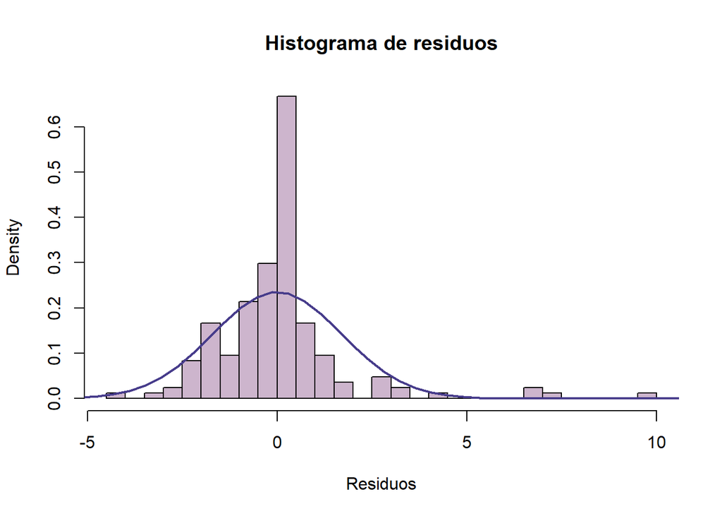

```r
hist(modelo4$residuals, breaks= 20,main="Histograma de residuos", col="thistle3", xlab = "Residuos", freq = FALSE)
curve(dnorm(x, mean(modelo4$residuals), sd = sd(modelo4$residuals)), # Función dnorm a evaluar
      -50, 20,168, # Límites de x y nº de valores a evaluar
      col = "slateblue4",
      lwd= 2,
      las = 1, # Etiquetas alineadas horizontalmente
      ann = FALSE, # Sin títulos en los ejes
      xaxp = c(-15, 15, 5),  # Marcas del eje x
      ylim = c(0,0.5), # Límites del eje
      yaxs = "i", add=TRUE) # Estilo del eje y, ajustado a los límites
```

**Observaciones:**

- Residuales
  - La media de los residuos es 1.8493553^{-17}, cuyo valor es cercano a 0.
  - La gráfica esta sesgada a la derecha.
- Coeficientes
  - Intercepto: Para una significancia de 0.05, se rechaza la H0, así que b≠0.
  - Pendientes: Para una significancia de 0.05, se rechaza la H0 (m=0), es decir, que sí existe relación entre las variables.
- R^2 Ajustado
  - El modelo se adecúa para el 48% de los datos de nuestra muestra.
- p-value
  - Para una significancia de 0.05, se rechaza la H0 de que el modelo no explica nada, es decir, que la cantidad de contagiados se explica con el tamaño familiar en los hogares en los que si hubo miembros contagiados.

```r
(modelo4$coefficients)
```

```
##      (Intercept)    DFN$Tfamiliar DFN$Contagiadosi
##       -0.9452556        0.2156780        3.0597838
```

*Ecuación de predicción:*

**Cantidad de contagiados = -0.9452556 + (0.2156780*Tfamiliar) + (3.0597838* Contagiados)**

#### 10. **Conclusiones**

BIBLIOGRAFÍA:

- Organización Mundial de la Salud[OMS] (2013). Salud Mental. Recuperado de https://www.who.int/topics/mental_health/es/#:~:text=La%20salud%20mental%20abarca%20una,ausencia%20de%20afecciones%20o%20enfermedades%C2%BB.
- DF: Cengage Learning Editores, S.A. de.
- Ortiz, R. (5 de Enero de 2016). RPubs by RStudio. Obtenido de https://rpubs.com/Rortizdu/140112
- R para principiantes. (s.f.). Obtenido de https://bookdown.org/jboscomendoza/r-principiantes4/leyendas.html Rcoder. (s.f.). Obtenido de https://r-coder.com/leyenda-r/